[figure not shown]

# Cycle Forecast for the New York Market

Michael Whitehouse

2026-09-30

## Model Context

| Metric | Value |
| --- | --- |
| As Of Date | 2026-09-28 |
| Horizon (Days) | 90 |
| Market | New York |
| Completion Fit Iterations | 9 |
| Cancellation Fit Iterations | 10 |
| Expected Procedures (90d) | 141.7 |

## How This Forecast Works

This report predicts cycle volume for the next 90 days in the New York market.

The model uses a daily snapshot table. Each row is one cycle at one point in time. The model learns how likely a cycle is to complete or cancel, based on current stage and patient factors.

The forecast has three parts:

1. Active cycles in the pipeline
2. New starts expected from current NPV flow
3. Return cycles from prior patients

The model runs backtests on recent cutoffs. Backtests compare forecast values to true observed values. This gives error metrics and interval bands.

Use this report to answer two questions:

1. How much work volume is expected by day and by month
2. Where the volume comes from, and how stable the model is over time

### Covariates used in the model

The forecast is built from a cause-specific survival model that uses the following patient and cycle features to predict completion and cancellation risk:

- `patient_age_c`: patient age, centered so the model compares the effect of age relative to a typical case.
- `patient_insurance_status`: coverage type, whether Kindbody employer benefit, self-pay, or other insurance.
- `attempt_type`: KindEMR cycle type (e.g. egg freezing, IVF, FET, oocyte thaw).
- `first_attempt`: whether this is the patient’s first treatment attempt.
- `prior_cancel_cat`: prior cancellation history, grouped into a small set of categories to capture repeat-cycle risk.
- `current_stage`: the patient’s current treatment stage in the cycle (e.g. new patient visit, cycle plan entered, cycle started)
- `log_days_in_stage`: the log of how long the patient has been in the current stage.
- `log_monthly_npvs`: the log of monthly new patient volume, which helps capture demand and referral momentum.
- `season_[sin/cos 1-2]`: cyclic terms to capture seasonality (2 sine and 2 cosine transformations of the month).

## Actual Procedure Counts by Year

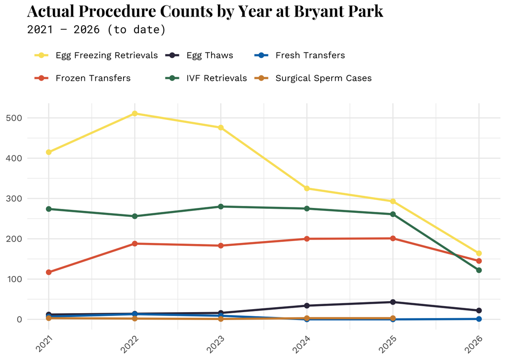

| Procedure | 2021 | 2022 | 2023 | 2024 | 2025 | 2026 |
| --- | --- | --- | --- | --- | --- | --- |
| Egg Freezing Retrievals | 415 | 511 | 476 | 325 | 293 | 164 |
| Egg Thaws | 12 | 14 | 16 | 34 | 43 | 22 |
| Fresh Transfers | 7 | 13 | 9 | 0 | 0 | 1 |
| Frozen Transfers | 117 | 188 | 183 | 200 | 201 | 145 |
| IVF Retrievals | 274 | 256 | 280 | 275 | 261 | 122 |
| Surgical Sperm Cases | 3 | 2 | 1 | 3 | 3 | NA |

## Patient Coverage Mix

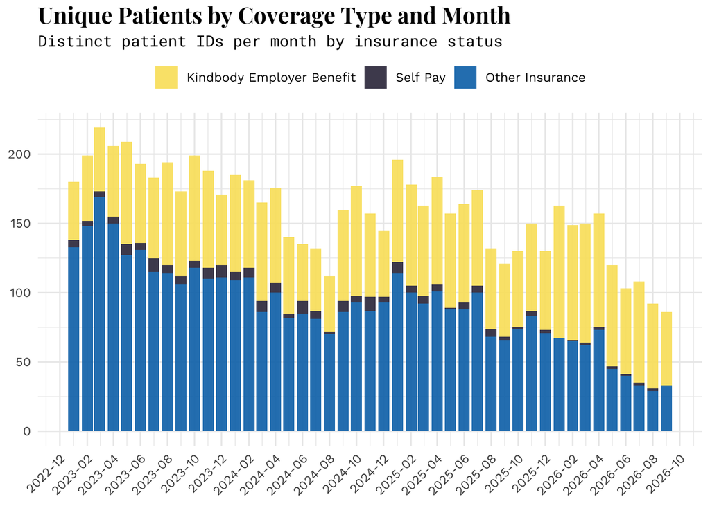

| Coverage Type | Unique Retrieval Cycles | Share of Retrievals |
| --- | --- | --- |
| Kindbody Employer Benefit | 1651 | 46.5% |
| Self Pay | 92 | 2.6% |
| Other Insurance | 1804 | 50.9% |

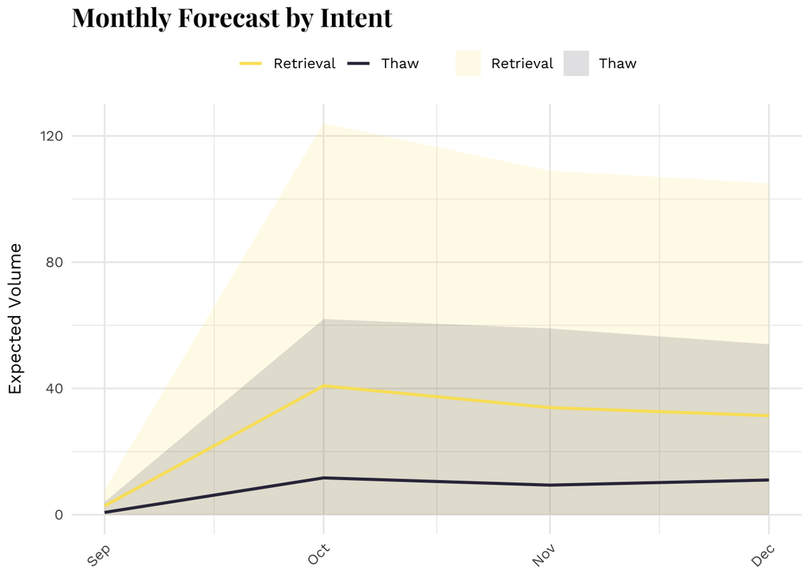

## Forecast for Next 90 Days

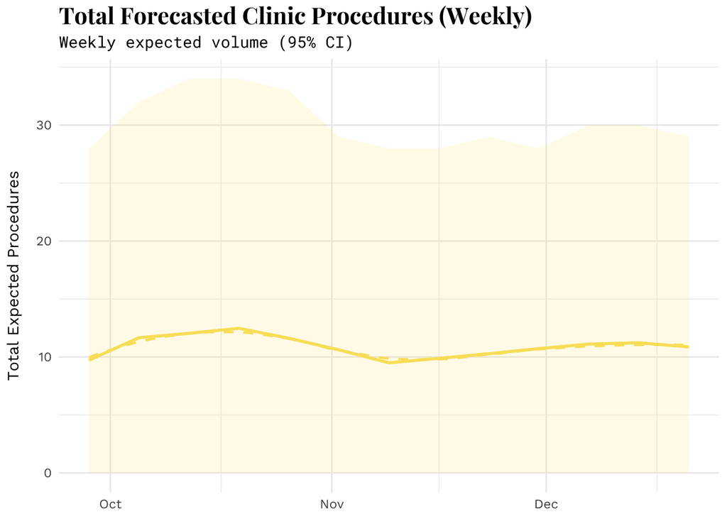

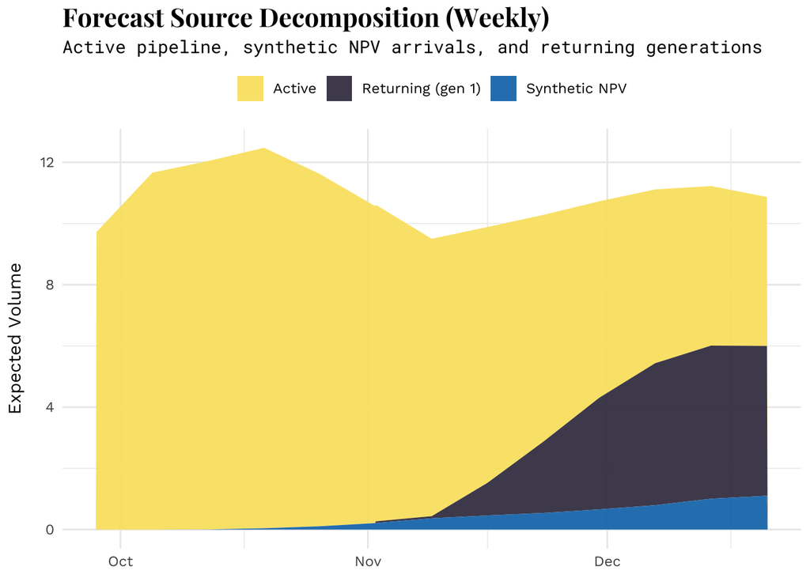

## New Patient Visits by Provider

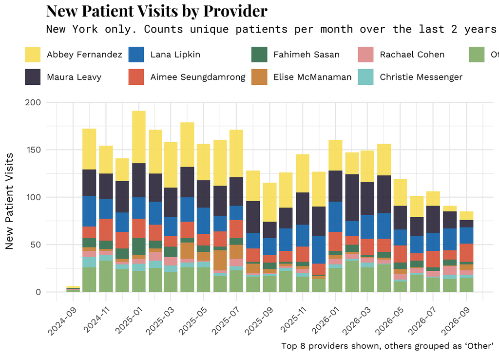

## Past Appointments Completed/Future Appointments Booked in 2026(New York)

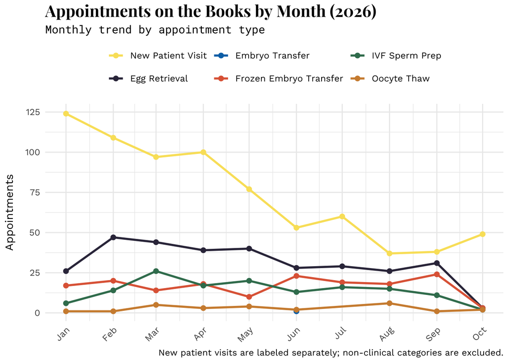

## Cycle Starts by Attempt Type and Provider

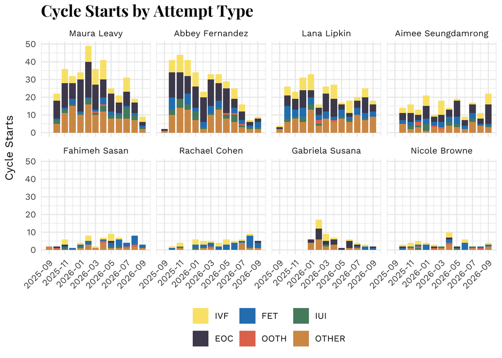

## Backtest Metrics by Cutoff

[figure not shown]

## Predicted vs Actual Lab Procedures, With 90-Day Forecast

#### 2-Year Backtest Window + 90-Days

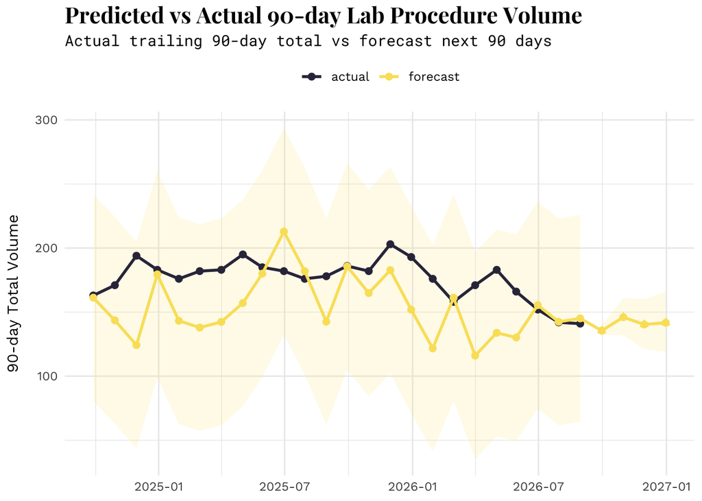

## Forecasted Cycle Starts by Attempt Type

#### Assumes recent attempt type shares (i.e. balance of egg freezing vs. IVF retrievals) remain similar for the next 90 days.

| Cycle Intent | Attempt Type | Share | Observed Count |
| --- | --- | --- | --- |
| Retrieval | Egg Freezing | 52.7% | 1538 |
| Retrieval | IVF Retrieval | 47.3% | 1378 |
| Thaw | Embryo Thaw | 92.7% | 1590 |
| Thaw | Oocyte Thaw | 7.3% | 126 |

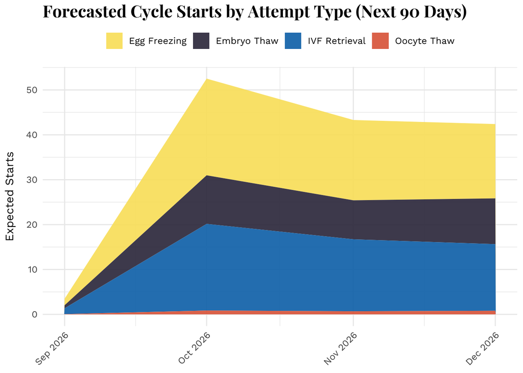

## Conclusion: Predicted Starts by Attempt Type (Oct-Nov-Dec)

[output not shown]